# Amundsen 2021 - Analyses

Pierre Priou - pierre.priou@mi.mun.ca

2022-07-25

```r
# Load packages
library(tidyverse)    # Tidy code
library(lubridate)    # Date handling
library(dtplyr)       # Speed up code
library(plotly)       # Interactive plots
library(oce)          # Speed of sound and absorption coefs.
library(cowplot)      # Multiple plots
library(lemon)        # Facets
library(rgdal)        # Read shapefiles
library(marmap)       # Bathymetry data of the Arctic Ocean
library(cmocean)      # Colour palettes
library(photobiology) # Assign rgb colour to wavelength
source("R/sv_depth_correction_fm.R")  # Correct Sv vertical profiles

# Suppress summarise() warning
options(dplyr.summarise.inform = F)

# Theme for figures
theme_set(theme_bw())
theme_update(panel.grid = element_blank(),
             panel.border = element_blank(),
             axis.line = element_line(),
             axis.text = element_text(size = 10),
             axis.title = element_text(size = 11),
             legend.title = element_text(size = 11),
             strip.text.x = element_text(size = 11, face = "plain",
                                         hjust = 0.5),
             strip.background = element_rect(colour = "transparent",
                                             fill = "transparent"),
             legend.margin = margin(0, 0, 0, 0),
             legend.box.margin = margin(0, 0, -8, 0),
             plot.margin = unit(c(0.05, 0.05, 0.05, 0.05), "in"))
```

# Introduction

Diel vertical migrations (DVM) from ocean’s depth to the surface are a ubiquitous pattern of pelagic organisms of the global ocean (Cohen 2009). While DVM are ultimately driven by predator-prey interactions (e.g., Urmy et al. 2021), environmental factors are known to define the extent and timing of these migrations. For example, temperature and oxygen can influence DVM patterns (Bianchi et al. 2013, Benoit-Bird et al. 2015?), but light penetration is considered to trump those other environmental cues (Asknes et al. 2017). Fish living in the mesopelagic zone, where the light intensity is between 10<sup>-9</sup> to 10<sup>-1</sup> μmol quanta m<sup>2</sup> s<sup>-1</sup> (Kaartvedt et al., 2019), track a narrow range of ambient light levels—their light comfort zone (Rostad 2016)—and migrate vertically following those isolumes during the day-night cycle. They track their antipredation window, which enhance their feeding chances while reducing mortality through predation (Clark & Levy, 1988).

The goals of this study were two-fold, (1) investigate whether mesopelagic organisms conduct DVM in autumn, and (2) if those organisms were associated to a specific range of ambient light levels matching those of the global ocean. Here, we deployed a combination of acoustic, optical, and environmental sensors and nets to document the vertical distribution of pelagic fish and zooplankton in northern Baffin Bay in autumn. We test the hypothesis that pelagic organisms follow a narrow range of light levels (different from the “new” definition of the mesopelagic zone) and thus conduct DVM.

# Materials and methods

```r
# Load data
bathy <- read_csv("data/bathy/bathy_BaffinBay_-105;-45;65;82_res2.csv",
                  show_col_types = F) %>%
  mutate(depth_d = factor(case_when(between(depth, -50, Inf) ~ "0-50",
                                    between(depth, -100, -50) ~ "50-100",
                                    between(depth, -200, -100) ~ "100-200",
                                    between(depth, -500, -200) ~ "200-500",
                                    between(depth, -1000, -500) ~ "500-1000",
                                    between(depth, -Inf, -1000) ~ "1000-2500"),
                          levels = c("0-50", "50-100", "100-200", "200-500", "500-1000", "1000-2500")))
coast <- readOGR("data/bathy/ne_10m_land.shp", verbose = F) %>% # Coastlines
  fortify() %>%
  rename(lon = long,
         region = id)
```

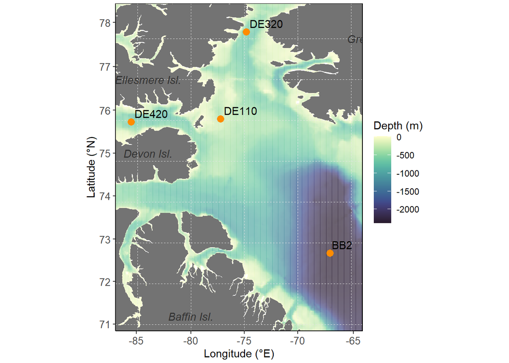

```r
tibble(lat = c(72.7491, 75.9631, 76.0355, 78.1672),
       lon = c(-67.0011, -85.5952, -77.2374, -74.8258),
       station = c("BB2", "DE420", "DE110", "DE320")) %>%
  # Map
  ggplot() +
  # Bathymetry
  geom_tile(data = filter(bathy, depth <= 20),
            aes(x = lon, y = lat, fill = depth),
            alpha = 0.7) +
  scale_fill_cmocean("Depth (m)", name = "deep", discrete = F, direction = -1) +
  # Coastlines
  geom_polygon(data = coast, aes(x = lon, y = lat, group = group),
               fill = "grey45") +
  # Longitude lines
  geom_segment(aes(x = -90, xend = -90, y = 60, yend = 90), col = "grey90", size = 0.3, lty = 2) +
  geom_segment(aes(x = -85, xend = -85, y = 60, yend = 90), col = "grey90", size = 0.3, lty = 2) +
  geom_segment(aes(x = -80, xend = -80, y = 60, yend = 90), col = "grey90", size = 0.3, lty = 2) +
  geom_segment(aes(x = -75, xend = -75, y = 60, yend = 90), col = "grey90", size = 0.3, lty = 2) +
  geom_segment(aes(x = -70, xend = -70, y = 60, yend = 90), col = "grey90", size = 0.3, lty = 2) +
  geom_segment(aes(x = -65, xend = -65, y = 60, yend = 90), col = "grey90", size = 0.3, lty = 2) +
  geom_segment(aes(x = -60, xend = -60, y = 60, yend = 90), col = "grey90", size = 0.3, lty = 2) +
  scale_x_continuous("Longitude (°E)",
                     breaks = c(-85.12, -80.02, -75, -70, -64.78),
                     labels = seq(-85, -65, 5)) +
  # Latitude lines
  geom_segment(aes(x = -120, xend = 0, y = 71, yend = 71), col = "grey90", size = 0.3, lty = 2) +
  geom_segment(aes(x = -120, xend = 0, y = 72, yend = 72), col = "grey90", size = 0.3, lty = 2) +
  geom_segment(aes(x = -120, xend = 0, y = 73, yend = 73), col = "grey90", size = 0.3, lty = 2) +
  geom_segment(aes(x = -120, xend = 0, y = 74, yend = 74), col = "grey90", size = 0.3, lty = 2) +
  geom_segment(aes(x = -120, xend = 0, y = 75, yend = 75), col = "grey90", size = 0.3, lty = 2) +
  geom_segment(aes(x = -120, xend = 0, y = 76, yend = 76), col = "grey90", size = 0.3, lty = 2) +
  geom_segment(aes(x = -120, xend = 0, y = 77, yend = 77), col = "grey90", size = 0.3, lty = 2) +
  geom_segment(aes(x = -120, xend = 0, y = 78, yend = 78), col = "grey90", size = 0.3, lty = 2) +
  geom_segment(aes(x = -120, xend = 0, y = 79, yend = 79), col = "grey90", size = 0.3, lty = 2) +
  scale_y_continuous("Latitude (°N)",
                     breaks = c(71.01, 72.05, 73.09, 74.15, 75.2, 76.25, 77.32, 78.4),
                     labels = seq(71, 78, 1)) +
  # Labels
  annotate("text", y = 77, x = -84, label = "Ellesmere Isl.", color = "grey20", fontface = "italic") +
  annotate("text", y = 75.2, x = -84, label = "Devon Isl.", color = "grey20", fontface = "italic") +
  annotate("text", y = 78, x = -63, label = "Greenland", color = "grey20", fontface = "italic") +
  annotate("text", y = 71.2, x = -80, label = "Baffin Isl.", color = "grey20", fontface = "italic") +
  # Stations
  geom_point(aes(x = lon, y = lat), col = "darkorange", size = 3) +
  geom_text(aes(x = lon, y = lat, label = station), col = "black", hjust = -0.1, vjust = -0.5) +
  # Change map projection
  # coord_map("azequidistant", ylim = c(70.8, 78.5), xlim = c(-86, -65)) +
  coord_quickmap(ylim = c(71.2, 78.5), xlim = c(-86, -65)) +
  theme(panel.border = element_rect(fill = "transparent"))
```

*Figure 1.* Map of northern Baffin Bay with locations of sampling stations (orange circles).

## Environmental data

A Seabird SBE911+ Conductivity Temperature Depth sensor (CTD) collected vertical profiles of temperature, salinity, and pressure. The CTD rosette was also equipped with an oxygen sensor (Seabird SBE43), a transmissometer (Wetlab Cstar), two fluorimeters (Seabird SCF and ECO CDOM), two PAR sensors (one underwater Biospherical Instruments PAR-QCP 2300, and surface Biospherical Instruments PAR-QCP 2200), and a nitrate sensor (Satlantic). We only considered downcast data.

```r
# Load CTD data
CTD_raw <- read_csv("data/CTD/CTD_Amundsen_2021_all_leg.csv", show_col_types = F)
```

Select relevant CTD stations (2, 13, 25, 26, 28, 29, and 40).

```r
CTD <- CTD_raw %>%
  # Select data from leg 5
  filter(leg == 5) %>%
  # # Select CTD casts
  # filter(cast_number %in% c(2, 13, 25, 26, 28, 29, 40)) %>%
  # Select variables of interest
  dplyr::select(station, cast_number, date, lat, lon, bottom_depth, depth_min,
                depth_max, PRES, TE90, PSAL, SIGM, SIGT, SIGP) %>%
  # Rename variable
  rename(date_start_CTD = date) %>%
  # Calculate depth from pressure
  mutate(depth = round(swDepth(pressure = PRES, latitude = lat))) %>%
  # Summarise data per 1 m depth bin
  group_by(date_start_CTD, station, cast_number, lat, lon, bottom_depth,
           depth_min, depth_max, depth) %>%
  summarise_all(mean) %>%
  ungroup()
```

Cast 25 is full of `NaNs` so I replace these values with the appropriate data that I processed myself.

```r
# Load CTD25 data
CTD25 <- read_csv("data/CTD/CTD25_1m.csv", show_col_types = F)

CTD <- CTD %>%
  # Combine CTD25
  left_join(., CTD25, by = c("date_start_CTD", "station",
                             "cast_number", "depth")) %>%
  # Update values of CTD25
  mutate(PRES = if_else(cast_number == 25 & is.na(PRES) == T, PRES_25, PRES),
         TE90 = if_else(cast_number == 25 & is.na(TE90) == T, TE90_25, TE90),
         PSAL = if_else(cast_number == 25 & is.na(PSAL) == T, PSAL_25, PSAL),
         SIGT = if_else(cast_number == 25 & is.na(SIGT) == T, SIGT_25, SIGT),
         SIGP = if_else(cast_number == 25 & is.na(SIGP) == T, SIGP_25, SIGP)) %>%
  # Remove CTD25 variables
  dplyr::select(-PRES_25, -TE90_25, -PSAL_25, -FLOR_25, -SIGT_25, -SIGP_25) %>%
  # Convert station to factor
  mutate(station = factor(station))

# Remove CTD25
rm(CTD25)
```

Fluorescence was also absent from the processed data so I calculated the mean fluorescence per 1 m depth bin myself and add them to the CTD dataset.

```r
# Load fluorescence data
fluo <- read_csv("data/CTD/CTD_fluorescence_1m.csv", show_col_types = F)

CTD <- CTD %>%
  # Combine fluorescence to CTD
  left_join(., fluo, by = c("cast_number", "depth")) %>%
  # Rename variables
  rename(pres = PRES,
         te90 = TE90,
         psal = PSAL) %>%
  # Remove unused variables
  dplyr::select(-SIGM, -SIGT, -SIGP)

# Remove fluorescence data
rm(fluo)
```

## Wideband Acoustic Transceiver (WBAT)

Broadband acoustic backscatter was recorded between 36-45 kHz and 283-333 kHz with a Simrad WBAT mounted on the CTD rosette. The transducers were facing sideward, pulse length was set to 2048 μs, power to and ping rate to 0.5 Hz. Acoustic data was analyzed with Echoview 12. WBAT acoustic backscatter data was manually inspected and cleaned. Data within the near-field was excluded (5.00 m). Using pulse compressed data, we exported mean volume backscatter strength (S<sub>V</sub>; dB re 1 m<sup>-1</sup>) and nautical area scattering coefficient (s<sub>A</sub>; m<sup>2</sup> nmi<sup>-2</sup>) at a resolution of 1 ping per 1 m range.

```r
# Load WBAT data
WBAT_raw <- list.files("data/WBAT", pattern = "*.csv", full.names = T) %>%
  set_names() %>%
  # Read files
  map_dfr(.f = ~read_csv(., show_col_types = F), .id = "filename") %>%
  # Tidy data
  unite(date_WBAT, Date_S, Time_S, sep = " ", remove = F) %>%
  mutate(station = str_extract(filename, pattern = "[A-Z]{2}[0-9]{3}"),
         station = if_else(str_detect(station, "BB") == T, "BB2", station),
         station = factor(station),
         CTD_id = str_extract(filename, pattern = "CTD[0-9]{2}"),
         CTD_id = as.numeric(str_remove(CTD_id, pattern = "CTD")),
         date_WBAT = round_date(ymd_hms(date_WBAT, tz = "UTC"), "second"),
         Frequency = factor(Frequency)) %>%
    rename(range = Layer_depth_min,
           frequency = Frequency,
           cast_number = CTD_id)
```

For CTD casts 2 and 13, the WBAT was activated with a pressure switch at 8 m depth. However, this switch malfunctioned on October 18<sup>th</sup>. Thus, before deploying the WBAT we synchronized the WBAT and CTD clocks manually. We extracted the mean depth at each second from raw CTD measurements (see `R\CTD_date_depth.R` for more details) and match them to the WBAT time.

To verify that the calculation of the WBAT depth was correct, we compared the WBAT S<sub>V</sub> profile at 38 kHz with profiles of the EK80 from the same station. If there was a mismatch in depth, we adjusted the WBAT depth manually. I only considered data collected during the downcast.

```r
# Load CTD depth
CTD_date_depth <- read_csv("data/CTD/CTD_date_depth.csv", show_col_types = F)

# Correct WBAT time
WBAT_time_corrected <- WBAT_raw %>%
  dplyr::select(date_WBAT, station, cast_number, Ping_S, frequency, range,
                Sv_mean, NASC) %>%
  # Fix dates
  mutate(date =
           case_when(cast_number == 2 ~ date_WBAT - hours(4) + seconds(50),
                     cast_number == 13 ~ date_WBAT - hours(4) + seconds(40),
                     cast_number == 25 ~ date_WBAT + seconds(16),
                     cast_number == 26 ~ date_WBAT + seconds(16),
                     cast_number == 28 ~ date_WBAT + seconds(16),
                     cast_number == 29 ~ date_WBAT + seconds(16),
                     cast_number == 40 ~ date_WBAT - hours(4) + seconds(25))) %>%
  # Combine CTD date at depth and WBAT date
  left_join(., CTD_date_depth, by = c("cast_number", "date")) %>%
  # Round depth
  rename(depth_raw = depth) %>%
  mutate(depth = floor(depth_raw)) %>%
  # Reorder variables
  dplyr::select(date_WBAT, date_start_CTD, station, cast_number, cast,
                frequency, depth_raw, depth, range, Sv_mean, NASC) %>%
  # Select data collected during downcast
  filter(cast == "downcast")

# Remove CTD date depth data
rm(CTD_date_depth)
```

Because the WBAT was mounted on a probe and collected data vertically, I corrected S<sub>V</sub> for changes in speed of sound and absorption coefficients with depth. To do that, I create a CTD dataset with all the required variables.

```r
# CTD with speed of sound and absorption coefficients
CTD_Sv_correction <- CTD %>%
    # Calculate speed of sound (m/s) and absorption coefficients (dB/m) at 38 and 333 kHz
    mutate(sound_speed =
             swSoundSpeed(salinity = psal, temperature = te90, pressure = pres,
                          longitude = lon, latitude = lat, eos = "gsw"),
           abs38 =
             swSoundAbsorption(frequency = 38000, salinity = psal,
                               temperature = te90, pressure = pres, pH = 8,
                               formulation = "francois-garrison"),
           abs333 =
             swSoundAbsorption(frequency = 333000, salinity = psal,
                               temperature = te90, pressure = pres, pH = 8,
                               formulation = "francois-garrison")) %>%
  # Keep only relevant variables
  dplyr::select(date_start_CTD, station, cast_number, lat, lon, depth,
                sound_speed, abs38, abs333)
```

Then, I match that CTD dataset with the WBAT data and correct S<sub>V</sub>.

```r
WBAT_cor <- WBAT_time_corrected %>%
  # Combine WBAT and speed of sound and absorption coefficients
  left_join(., CTD_Sv_correction,
            by = c("date_start_CTD", "station", "cast_number", "depth")) %>%
  # Correct Sv according to sound speed and absorption for every depth bin
  mutate(Sv_cor =
           case_when(frequency == 38 ~
                       sv_depth_correction_fm(Sv = Sv_mean,
                                              range = range,
                                              f_nominal = 38,
                                              f_start = 36,
                                              f_end = 45,
                                              c_cal = 1450,
                                              t_cal = 0.12351,
                                              psi_cal = -12.5,
                                              p_cal = 450,
                                              abs_depth_cal = 300,
                                              pH_cal = 8,
                                              sal_cal = 34,
                                              temp_cal = 0,
                                              lat = lat,
                                              c_new = sound_speed,
                                              abs_new = abs38),
                     frequency == 333 ~
                       sv_depth_correction_fm(Sv = Sv_mean,
                                              range = range,
                                              f_nominal = 38,
                                              f_start = 36,
                                              f_end = 45,
                                              c_cal = 1450,
                                              t_cal = 0.12351,
                                              psi_cal = -12.5,
                                              p_cal = 450,
                                              abs_depth_cal = 300,
                                              pH_cal = 8,
                                              sal_cal = 34,
                                              temp_cal = 0,
                                              lat = lat,
                                              c_new = sound_speed,
                                              abs_new = abs333))) %>%
  dplyr::select(-sound_speed, -abs38, -abs333, -depth_raw)

# Remove unused data
rm(WBAT_time_corrected, CTD_Sv_correction)
```

Because the sampling resolution of the WBAT was ca. 1 ping / 2 m, I calculate the average S<sub>V</sub> in 5 m depth bins.

```r
WBAT_bin <- WBAT_cor %>%
  # Calculate Sv mean and SD for each 5 m depth bin
  mutate(depth_round = plyr::round_any(depth, 5, floor)) %>%
  group_by(date_start_CTD, lat, lon, station, cast_number, frequency, depth_round, range) %>%
  summarise(Sv_cor_mean = mean(Sv_cor),
            Sv_cor_SD = sd(Sv_cor)) %>%
  ungroup()

# Remove unused data
rm(WBAT_cor)
```

The signal-to-noise ratio (SNR) was good over the entire range (0-100 m) at 38 kHz although there seemed to be some rosette avoidance (Figure 2). At 333 kHz, the SNR was relatively low at higher ranges (> 60 m). Echoview 12.1 cannot evaluate background noise and SNR, however Echoview 13 will be able to do it. Thus, for now, we constrained our analyses to 10 - 95 m range at 38 kHz, and 10 - 60 m at 333 kHz.

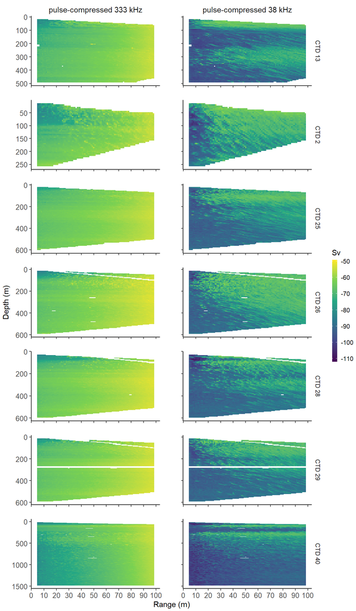

```r
WBAT_bin %>%
  mutate(frequency = paste0("pulse-compressed ", frequency, " kHz"),
         cast_number = paste0("CTD ", cast_number)) %>%
  ggplot(aes(x = range, y = depth_round, fill = Sv_cor_mean)) +
  geom_tile() +
  scale_fill_viridis_c(name = "Sv") +
  scale_x_continuous("Range (m)", breaks = seq(0, 100, 10)) +
  scale_y_reverse("Depth (m)") +
  facet_rep_grid(cast_number ~ frequency, scales = "free_y") +
  theme(legend.key.height = unit(0.4, "in"),
        legend.key.width = unit(0.1, "in"))
```

*Figure 2.* Echograms of volume backscattering strength (S<sub>V</sub> in dB re 1 m<sup>-1</sup>) at 333 kHz (left) and 38 kHz (right) for each CTD cast. Note the difference depth scale between CTD casts.

```r
WBAT <- WBAT_bin %>%
  # Select ranges with good SNR
  mutate(keep = case_when(frequency == 38 ~ if_else(between(range, 10, 95), T, F),
                          frequency == 333 ~ if_else(between(range, 10, 60), T, F)))
```

**FREQUENCY RESPONSES**

## Underwater Vision Profiler 6 (UVP)

```r
# Load UVP data
UVP_raw <- read_csv("data/UVP/plank_PC_values.csv", show_col_types = F)
```

```r
UVP <- UVP_raw %>%
  # Rename variables to match other datasets
  rename(cast_number = ctd_file,
         depth_UVP = depth,
         group = taxon) %>%
  # Tidy variables
  unite(date_UVP, date, time, sep = " ") %>%
  mutate(date_UVP = ymd_hms(date_UVP),
         station = if_else(station == "DEBB2", "BB2", station),
         station = factor(station),
         cast_number = as.numeric(cast_number),
         taxa =
           case_when(str_detect(lineage, "Amphipoda") == T ~ "Amp",
                     str_detect(lineage, "Annelida") == T ~ "Ann",
                     str_detect(lineage, "Appendicularia") == T ~ "App",
                     str_detect(lineage, "Chaetognatha") == T ~ "Cha",
                     str_detect(lineage, "Siphonophorae") == T ~ "Sip",
                     str_detect(lineage, "Cnidaria") == T ~ "Cni",
                     str_detect(lineage, "Copepoda") == T ~ "Cop",
                     str_detect(lineage, "Ctenophora") == T ~ "Cte",
                     str_detect(lineage, "Eumalacostraca") == T ~ "Eum",
                     str_detect(lineage, "Limacinidae") == T ~ "Lim",
                     str_detect(lineage, "Ostracoda") == T ~ "Ost",
                     str_detect(lineage, "Salpida") == T ~ "Sal",
                     str_detect(lineage, "Rhizaria") == T ~ "Rhi")) %>%
  # Select variables of interest
  dplyr::select(date_UVP, station, cast_number, ice, depth_UVP, group, lineage,
                taxa) %>%
  # Remove images with uncertain taxonomy
  filter(is.na(taxa) == F) %>%
  # Summarise data in 5 m bins
  mutate(depth_round = plyr::round_any(depth_UVP, 5, floor)) %>%
  group_by(station, cast_number, ice, depth_round, group, taxa) %>%
  summarise(count = n()) %>%
  ungroup()
```

## Light data

```r
COPS_raw <- read_csv("data/C-OPS/C-OPS_processed.csv", show_col_types = F)
```

At each station, three replicates were collected.

```r
COPS <- COPS_raw %>%
  # Select stations and wavelengths of interest
  filter(station %in% c("DE110", "DE320", "DE420") &
           between(wavelength, 400, 690)) %>%
  # Fix variable type
  mutate(station = factor(station),
         COPS_ID = factor(COPS_ID)) %>%
  # Calculate mean kz and edz per 1 m depth bin to match CTD resolution
  mutate(depth = round(depth)) %>%
  unite(ID, COPS_ID, wavelength, sep = "_", remove = F) %>%
  group_by(station, COPS_ID, ID, depth, wavelength, detection_levels, mean_edz_0m) %>%
  summarise(kz = mean(kz, na.rm = T),
            edz = mean(edz, na.rm = T)) %>%
  ungroup()
```

To extrapolate irradiance at the depth of the DSL I need to use the appropriate coefficient of extinction (kz) (Figure 3).

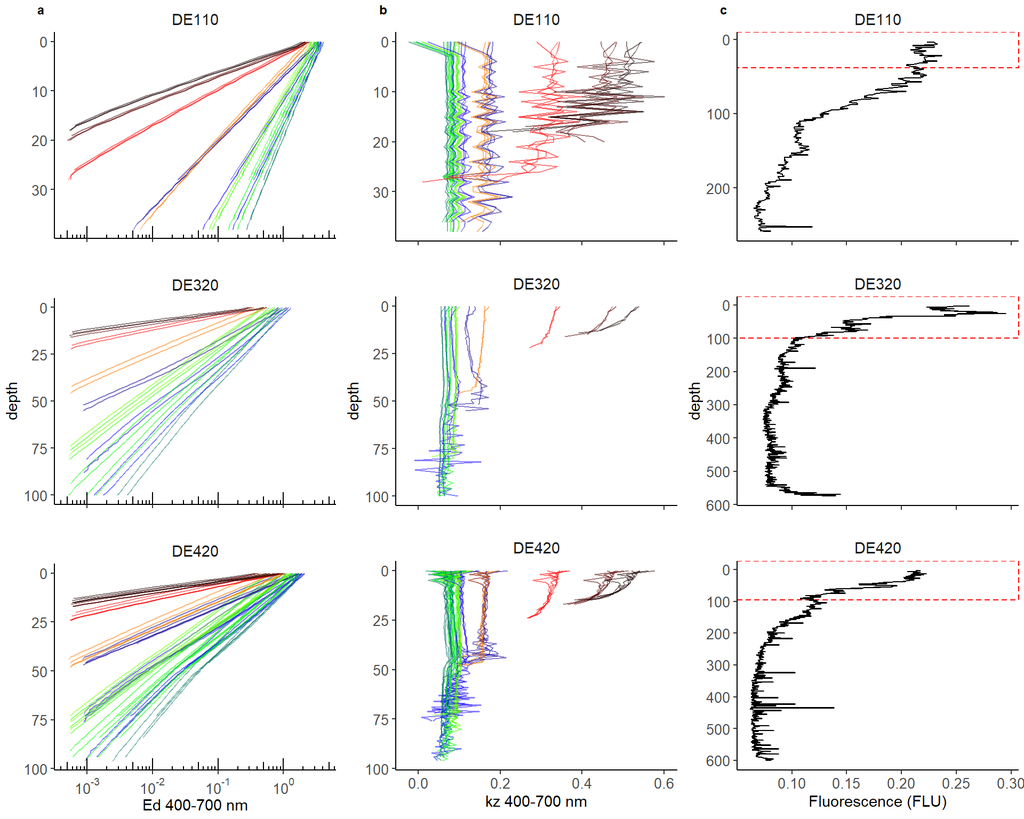

```r
# Combine fluo and CTD
COPS_fluo <- COPS %>%
  # Add CTD data
  left_join(., CTD, by = c("station", "depth")) %>%
  dplyr::select(station, ID, depth, wavelength, edz, kz, fluo)

# Color scale for edz and kz
col_pal <- w_length2rgb(c(412, 443, 465, 490, 510, 532, 555, 560, 589,
                          625, 665, 683)) %>%
  as_tibble() %>%
  as.matrix()

# Plot edz
p_edz <- COPS_fluo %>%
  filter(is.na(edz) == F) %>%
  ggplot() +
  geom_path(aes(x = edz, y = depth, col = factor(wavelength), group = ID),
            alpha = 0.5) +
  scale_x_log10(
    "Ed 400-700 nm",
    breaks = scales::trans_breaks("log10", function(x) 10 ^ x),
    labels = scales::trans_format("log10", scales::math_format(10 ^ .x))) +
  annotation_logticks(sides = "b") +
  scale_y_reverse() +
  scale_color_manual(values = col_pal) +
  facet_rep_wrap(~ station, scales = "free_y", ncol = 1) +
  theme(legend.position = "none")

# Plot kz
p_kz <- COPS_fluo %>%
  filter(is.na(kz) == F) %>%
  ggplot() +
  geom_path(aes(x = kz, y = depth, col = factor(wavelength), group = ID),
            alpha = 0.5) +
  scale_x_continuous("kz 400-700 nm") +
  scale_y_reverse() +
  scale_color_manual(values = col_pal) +
  facet_rep_wrap(~ station, scales = "free_y", ncol = 1) +
  theme(legend.position = "none")

# Plot fluo
p_fluo <- CTD %>%
  filter(cast_number %in% c(2, 13, 25) & fluo < 0.35) %>%
  mutate(ymax_box = case_when(station == "DE110" ~ 38,
                              station == "DE320" ~ 100,
                              station == "DE420" ~ 96)) %>%
  ggplot() +
  geom_rect(aes(xmin = -Inf, xmax = Inf, ymin = -Inf, ymax = ymax_box),
            col = "red", fill = NA, alpha = 0.05, lty = 2) +
  geom_path(aes(x = fluo, y = depth)) +
  scale_x_continuous("Fluorescence (FLU)") +
  scale_y_reverse(breaks = seq(0, 2000, 100)) +
  facet_rep_wrap(~ station, scales = "free_y", ncol = 1)

# Combine plots
plot_grid(p_edz, p_kz, p_fluo, align = "hv", axis = "tblr", ncol = 3,
          labels = "auto", label_size = 9, label_x = 0.1)
```

```r
# Remove unused data
rm(p_edz, p_kz, p_fluo, COPS_fluo, col_pal)
```

*Figure 3.* Vertical profile of (a) downwelling irradiance (Ed in µW cm<sup>-2</sup> nm<sup>-1</sup>) and (b) coefficient of extinction (kz in m<sup>-1</sup>) between 400 and 700 nm (colored lines), and (c) fluorescence (arbitrary units) at each station. The dashed red rectangles in (c) indicate the depth ranges where light data are available. Note the different y-axis scale for (c) the fluorescence.

For each wavelength, we calculated the mean kz (k<sub>mean</sub>) of the last 5 m of the profile. To extrapolate irradiance at mesopelagic depth, we used both k<sub>mean</sub> and the deepest kz (k<sub>max</sub>) available at each wavelength.

```r
# Mean kz over the last 5 m
kz_mean <- COPS %>%
  # Remove NAs
  filter(is.na(kz) == F) %>%
  # Find last 5 m of each wavelength at each station
  group_by(station, COPS_ID, ID, wavelength) %>%
  mutate(keep = if_else(max(depth) - depth <= 5, T, F)) %>%
  filter(keep == T) %>%
  summarise(kz_mean = mean(kz)) %>%
  ungroup() %>%
  # Keep relevant variables
  dplyr::select(station, COPS_ID, ID, wavelength, kz_mean)

# kz at max depth
kz_max_depth <- COPS %>%
  # Remove NAs
  filter(is.na(kz) == F) %>%
  # Find last 5 m of each wavelength at each station
  group_by(station, COPS_ID, ID, wavelength) %>%
  mutate(keep = if_else(max(depth) == depth, T, F)) %>%
  filter(keep == T) %>%
  rename(kz_max_depth = kz) %>%
  ungroup() %>%
  # Keep relevant variables
  dplyr::select(station, COPS_ID, ID, wavelength, kz_max_depth)
```

We extrapolated the ambient irradiance Ed<sub>z</sub> down to the seafloor using the following equation:
$$Ed_{z} = Ed_{0} . e ^ {-k . z}$$

where Ed<sub>z</sub> is the downwelling irradiance at depth z (in µW cm<sup>-2</sup> nm<sup>-1</sup>), Ed<sub>0</sub> the downwelling irradiance just below the surface in (µW cm<sup>-2</sup> nm<sup>-1</sup>), k is either the k<sub>mean</sub> or k<sub>max</sub> (in m<sup>-1</sup>), and z is the depth (in m).

```r
COPS_extra <- COPS %>%
  # Complete dataset to 602 m
  group_by(station, COPS_ID, ID, wavelength, mean_edz_0m) %>%
  complete(depth = seq(0, 602, 1)) %>%
  ungroup() %>%
  # Remove data below seafloor
  mutate(remove = case_when(station == "DE110" & depth > 260 ~ T,
                            station == "DE320" & depth > 575 ~ T)) %>%
  filter(is.na(remove) == T) %>%
  dplyr::select(-remove) %>%
  # Add kz mean and kz at max depth
  left_join(., kz_mean, by = c("station", "COPS_ID", "ID", "wavelength")) %>%
  left_join(., kz_max_depth, by = c("station", "COPS_ID", "ID", "wavelength")) %>%
  # Extrapolate edz
  mutate(edz_kz_mean = mean_edz_0m * exp(- kz_mean * depth),
         edz_kz_max = mean_edz_0m * exp(- kz_max_depth * depth))

# Remove unused data
rm(kz_max_depth, kz_mean)
```

# Results

## DE110

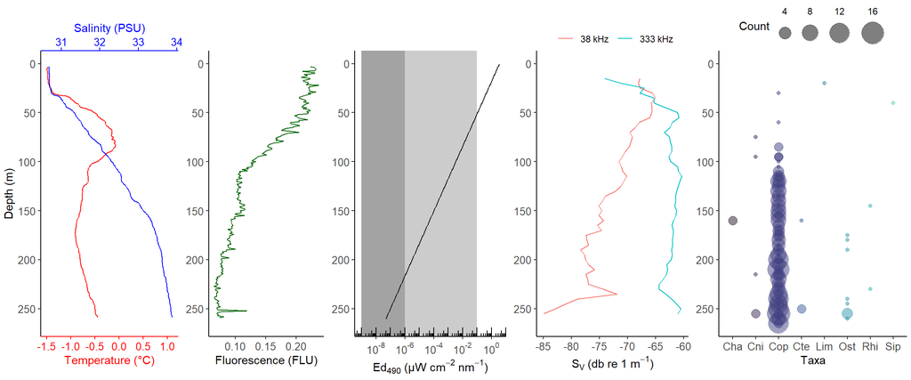

```r
# Coefficients for scaling salinity so that it can be plotted with temperature
b <- diff(c(-2, 2))/diff(c(30, 35))
a <- -2 - b * 30
# CTD plot
p_CTD <- CTD %>%
  filter(cast_number == 2) %>%
  ggplot() +
  # Temperature
  geom_path(aes(x = te90, y = depth, group = cast_number), col = "red", na.rm = T) +
  # Salinity
  geom_path(aes(x = a + psal * b, y = depth, group = cast_number), col = "blue", na.rm = T) +
  # Scales
  scale_x_continuous("Temperature (°C)", breaks = seq(-2, 10, 0.5),
                     sec.axis = sec_axis(~ (. - a)/b, name = "Salinity (PSU)",
                                         breaks = seq(0, 40, 1))) +
  scale_y_reverse("Depth (m)", limits = c(265, 0), breaks = seq(0, 1500, 50)) +
  theme(axis.line.x.bottom = element_line(color = "red"),
        axis.ticks.x.bottom = element_line(color = "red"),
        axis.text.x.bottom = element_text(color = "red"),
        axis.title.x.bottom = element_text(color = "red"),
        axis.line.x.top = element_line(color = "blue"),
        axis.ticks.x.top = element_line(color = "blue"),
        axis.text.x.top = element_text(color = "blue"),
        axis.title.x.top = element_text(color = "blue"))

# Fluorescence
p_fluo <- CTD %>%
  filter(cast_number == 2) %>%
  ggplot() +
  # Fluorescence
  geom_path(aes(x = fluo, y = depth, group = cast_number), col = "darkgreen", na.rm = T) +
  # Scales
  scale_x_continuous("Fluorescence (FLU)") +
  scale_y_reverse(limits = c(265, 0), breaks = seq(0, 1500, 50)) +
  theme(axis.title.y = element_blank())

# COPS
p_COPS <- COPS_extra %>%
  filter(station == "DE110" & wavelength == 490) %>%
  # Calculate mean profile over several casts at 490 nm
  group_by(wavelength, depth) %>%
  summarize(edz_kz_mean = mean(edz_kz_mean),
            edz_kz_max = mean(edz_kz_max)) %>%
  ggplot() +
  # Edz profile
  geom_path(aes(x = edz_kz_mean, y = depth), col = "black") +
  # Mesopelagic zone defined by Kaartvedt et al. 2019
  annotate("rect", xmin = 10^-9, xmax = 10^-1, ymin = -Inf, ymax = Inf,
           fill = "black", alpha = 0.2) +
  # Results from Asknes et al. 2017
  annotate("rect", xmin = 10^-9, xmax = 10^-6, ymin = -Inf, ymax = Inf,
           fill = "black", alpha = 0.2) +
  # Scales
  scale_x_log10(expression("Ed"[490]*" (µW cm"^-2*" nm"^-1*")"),
                breaks = scales::trans_breaks("log10", function(x) 10 ^ x),
                labels = scales::trans_format("log10", scales::math_format(10 ^ .x))) +
  annotation_logticks(sides = "b") +
  scale_y_reverse(limits = c(265, 0), breaks = seq(0, 1500, 50)) +
  theme(axis.title.y = element_blank())

# WBAT
p_WBAT <- WBAT %>%
  # Correct labels
  mutate(frequency = factor(paste0(frequency, " kHz"),
                            levels = c("38 kHz", "333 kHz"))) %>%
  filter(cast_number == 2) %>%
  # Calculate median Sv over the whole range (10-95m @38 kHz and 10-60m @ 333 kHz)
  group_by(depth_round, frequency) %>%
  summarise(Sv_mean = 10 * log10(mean(10 ^ (Sv_cor_mean / 10)))) %>%
  ungroup() %>%
  ggplot() +
  # Sv at 38 and 333 kHz
  geom_path(aes(x = Sv_mean, y = depth_round, col = frequency)) +
  # Scales
  scale_x_continuous(expression("S"[V]*" (db re 1 m"^-1*")"), breaks = seq(-150, 0, 5)) +
  scale_y_reverse(limits = c(265, 0), breaks = seq(0, 1500, 50)) +
  theme(legend.position = "top",
        legend.title = element_blank(),
        axis.title.y = element_blank())

# UVP
p_UVP <- UVP %>%
  filter(cast_number == 2) %>%
  ggplot() +
  # Count per 5 m depth
  geom_point(aes(x = taxa, y = depth_round, size = count, col = taxa), alpha = 0.5) +
  # Scales
  scale_x_discrete("Taxa") +
  scale_y_reverse(limits = c(265, 0), breaks = seq(0, 1500, 50)) +
  scale_size("Count", range = c(1.5, 10)) +
  scale_color_viridis_d(option = "mako", begin = 0.1, end = 0.8) +
  guides(color = "none",
         size = guide_legend(label.position = "top", label.vjust = -1)) +
  theme(legend.position = "top",
        axis.title.y = element_blank())#
        # axis.text.x = element_text(angle = -45, hjust = 0, vjust = 0.5))

# Combine plots
plot_grid(p_CTD, p_fluo, p_COPS, p_WBAT, p_UVP, nrow = 1, align = "h",
          axis = "tblr", rel_widths = c(1, 0.8, 1, 1, 1.2))
```

```r
# Remove unused data
rm(a, b, p_CTD, p_fluo, p_COPS, p_WBAT, p_UVP)
```

## DE320

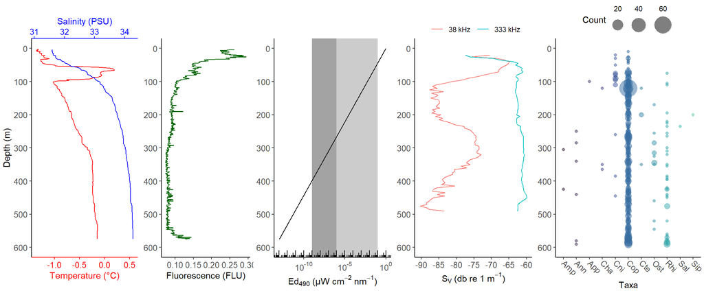

```r
# Coefficients for scaling salinity so that it can be plotted with temperature
b <- diff(c(-2, 1))/diff(c(30, 35))
a <- -2 - b * 30
# CTD plot
p_CTD <- CTD %>%
  filter(cast_number == 13) %>%
  ggplot() +
  # Temperature
  geom_path(aes(x = te90, y = depth, group = cast_number), col = "red", na.rm = T) +
  # Salinity
  geom_path(aes(x = a + psal * b, y = depth, group = cast_number), col = "blue", na.rm = T) +
  # Scales
  scale_x_continuous("Temperature (°C)", breaks = seq(-2, 10, 0.5),
                     sec.axis = sec_axis(~ (. - a)/b, name = "Salinity (PSU)",
                                         breaks = seq(0, 40, 1))) +
  scale_y_reverse("Depth (m)", limits = c(600, 0), breaks = seq(0, 1500, 100)) +
  theme(axis.line.x.bottom = element_line(color = "red"),
        axis.ticks.x.bottom = element_line(color = "red"),
        axis.text.x.bottom = element_text(color = "red"),
        axis.title.x.bottom = element_text(color = "red"),
        axis.line.x.top = element_line(color = "blue"),
        axis.ticks.x.top = element_line(color = "blue"),
        axis.text.x.top = element_text(color = "blue"),
        axis.title.x.top = element_text(color = "blue"))

# Fluorescence
p_fluo <- CTD %>%
  filter(cast_number == 13) %>%
  ggplot() +
  # Fluorescence
  geom_path(aes(x = fluo, y = depth, group = cast_number), col = "darkgreen", na.rm = T) +
  # Scales
  scale_x_continuous("Fluorescence (FLU)") +
  scale_y_reverse(limits = c(600, 0), breaks = seq(0, 1500, 100)) +
  theme(axis.title.y = element_blank())

# COPS
p_COPS <- COPS_extra %>%
  filter(station == "DE320" & wavelength == 490) %>%
  # Calculate mean profile over several casts at 490 nm
  group_by(wavelength, depth) %>%
  summarize(edz_kz_mean = mean(edz_kz_mean),
            edz_kz_max = mean(edz_kz_max)) %>%
  ggplot() +
  # Edz profile
  geom_path(aes(x = edz_kz_mean, y = depth), col = "black") +
  # Mesopelagic zone defined by Kaartvedt et al. 2019
  annotate("rect", xmin = 10^-9, xmax = 10^-1, ymin = -Inf, ymax = Inf,
           fill = "black", alpha = 0.2) +
  # Results from Asknes et al. 2017
  annotate("rect", xmin = 10^-9, xmax = 10^-6, ymin = -Inf, ymax = Inf,
           fill = "black", alpha = 0.2) +
  # Scales
  scale_x_log10(expression("Ed"[490]*" (µW cm"^-2*" nm"^-1*")"),
                breaks = scales::trans_breaks("log10", function(x) 10 ^ x),
                labels = scales::trans_format("log10", scales::math_format(10 ^ .x))) +
  annotation_logticks(sides = "b") +
  scale_y_reverse(limits = c(600, 0), breaks = seq(0, 1500, 100)) +
  theme(axis.title.y = element_blank())

# WBAT
p_WBAT <- WBAT %>%
  # Correct labels
  mutate(frequency = factor(paste0(frequency, " kHz"),
                            levels = c("38 kHz", "333 kHz"))) %>%
  filter(cast_number == 13) %>%
  # Calculate median Sv over the whole range (10-95m @38 kHz and 10-60m @ 333 kHz)
  group_by(depth_round, frequency) %>%
  summarise(Sv_mean = 10 * log10(mean(10 ^ (Sv_cor_mean / 10)))) %>%
  ungroup() %>%
  ggplot() +
  # Sv at 38 and 333 kHz
  geom_path(aes(x = Sv_mean, y = depth_round, col = frequency)) +
  # Scales
  scale_x_continuous(expression("S"[V]*" (db re 1 m"^-1*")"), breaks = seq(-150, 0, 5)) +
  scale_y_reverse(limits = c(600, 0), breaks = seq(0, 1500, 100)) +
  theme(legend.position = "top",
        legend.title = element_blank(),
        axis.title.y = element_blank())

# UVP
p_UVP <- UVP %>%
  filter(cast_number == 13) %>%
  ggplot() +
  # Count per 5 m depth
  geom_point(aes(x = taxa, y = depth_round, size = count, col = taxa), alpha = 0.5) +
  # Scales
  scale_x_discrete("Taxa") +
  scale_y_reverse(limits = c(600, 0), breaks = seq(0, 1500, 100)) +
  scale_size("Count", range = c(1.5, 10)) +
  scale_color_viridis_d(option = "mako", begin = 0.1, end = 0.8) +
  guides(color = "none",
         size = guide_legend(label.position = "top", label.vjust = -1)) +
  theme(legend.position = "top",
        axis.title.y = element_blank(),
        axis.text.x = element_text(angle = -45, hjust = 0, vjust = 0.5))

# Combine plots
plot_grid(p_CTD, p_fluo, p_COPS, p_WBAT, p_UVP, nrow = 1, align = "h",
          axis = "tblr", rel_widths = c(1, 0.8, 1, 1, 1.2))
```

```r
# Remove unused data
rm(a, b, p_CTD, p_fluo, p_COPS, p_WBAT, p_UVP)
```

## DE420

### Dawn - CTD25

Salinity is very off, need to check the raw files. Similarly, irradiance does not match with biological data because it was collected during at noon and the CTD cast was at down.

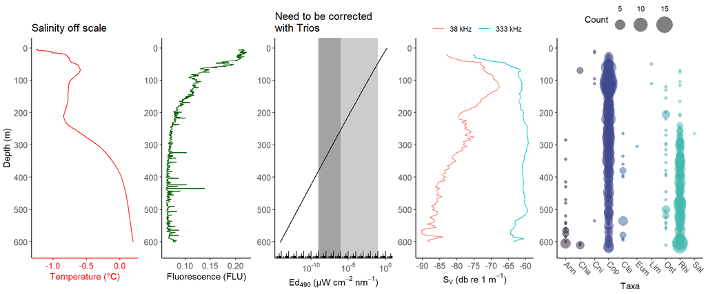

```r
# Coefficients for scaling salinity so that it can be plotted with temperature
b <- diff(c(-2, 2))/diff(c(30, 35))
a <- -2 - b * 30
# CTD plot
p_CTD <- CTD %>%
  filter(cast_number == 25) %>%
  ggplot() +
  # Temperature
  geom_path(aes(x = te90, y = depth, group = cast_number), col = "red", na.rm = T) +
  # Salinity
  # geom_path(aes(x = a + psal * b, y = depth, group = cast_number), col = "blue", na.rm = T) +
  # Cast need to account for time of day
  ggtitle("Salinity off scale") +
  # Scales
  scale_x_continuous("Temperature (°C)", breaks = seq(-2, 10, 0.5)) +#,
                     # sec.axis = sec_axis(~ (. - a)/b, name = "Salinity (PSU)",
                     #                     breaks = seq(0, 40, 1))) +
  scale_y_reverse("Depth (m)", limits = c(620, 0), breaks = seq(0, 1500, 100)) +
  theme(axis.line.x.bottom = element_line(color = "red"),
        axis.ticks.x.bottom = element_line(color = "red"),
        axis.text.x.bottom = element_text(color = "red"),
        axis.title.x.bottom = element_text(color = "red"),
        axis.line.x.top = element_line(color = "blue"),
        axis.ticks.x.top = element_line(color = "blue"),
        axis.text.x.top = element_text(color = "blue"),
        axis.title.x.top = element_text(color = "blue"))

# Fluorescence
p_fluo <- CTD %>%
  filter(cast_number == 25) %>%
  ggplot() +
  # Fluorescence
  geom_path(aes(x = fluo, y = depth, group = cast_number), col = "darkgreen", na.rm = T) +
  # Scales
  scale_x_continuous("Fluorescence (FLU)") +
  scale_y_reverse(limits = c(620, 0), breaks = seq(0, 1500, 100)) +
  theme(axis.title.y = element_blank())

# COPS
p_COPS <- COPS_extra %>%
  filter(station == "DE420" & wavelength == 490) %>%
  # Calculate mean profile over several casts at 490 nm
  group_by(wavelength, depth) %>%
  summarize(edz_kz_mean = mean(edz_kz_mean),
            edz_kz_max = mean(edz_kz_max)) %>%
  ggplot() +
  # Edz profile
  geom_path(aes(x = edz_kz_mean, y = depth), col = "black") +
  # Mesopelagic zone defined by Kaartvedt et al. 2019
  annotate("rect", xmin = 10^-9, xmax = 10^-1, ymin = -Inf, ymax = Inf,
           fill = "black", alpha = 0.2) +
  # Results from Asknes et al. 2017
  annotate("rect", xmin = 10^-9, xmax = 10^-6, ymin = -Inf, ymax = Inf,
           fill = "black", alpha = 0.2) +
  # Cast need to account for time of day
  ggtitle("Need to be corrected\nwith Trios") +
  # Scales
  scale_x_log10(expression("Ed"[490]*" (µW cm"^-2*" nm"^-1*")"),
                breaks = scales::trans_breaks("log10", function(x) 10 ^ x),
                labels = scales::trans_format("log10", scales::math_format(10 ^ .x))) +
  annotation_logticks(sides = "b") +
  scale_y_reverse(limits = c(620, 0), breaks = seq(0, 1500, 100)) +
  theme(axis.title.y = element_blank())

# WBAT
p_WBAT <- WBAT %>%
  # Correct labels
  mutate(frequency = factor(paste0(frequency, " kHz"),
                            levels = c("38 kHz", "333 kHz"))) %>%
  filter(cast_number == 25) %>%
  # Calculate median Sv over the whole range (10-95m @38 kHz and 10-60m @ 333 kHz)
  group_by(depth_round, frequency) %>%
  summarise(Sv_mean = 10 * log10(mean(10 ^ (Sv_cor_mean / 10)))) %>%
  ungroup() %>%
  ggplot() +
  # Sv at 38 and 333 kHz
  geom_path(aes(x = Sv_mean, y = depth_round, col = frequency)) +
  # Scales
  scale_x_continuous(expression("S"[V]*" (db re 1 m"^-1*")"), breaks = seq(-150, 0, 5)) +
  scale_y_reverse(limits = c(620, 0), breaks = seq(0, 1500, 100)) +
  theme(legend.position = "top",
        legend.title = element_blank(),
        axis.title.y = element_blank())

# UVP
p_UVP <- UVP %>%
  filter(cast_number == 25) %>%
  ggplot() +
  # Count per 5 m depth
  geom_point(aes(x = taxa, y = depth_round, size = count, col = taxa), alpha = 0.5) +
  # Scales
  scale_x_discrete("Taxa") +
  scale_y_reverse(limits = c(620, 0), breaks = seq(0, 1500, 100)) +
  scale_size("Count", range = c(1.5, 10)) +
  scale_color_viridis_d(option = "mako", begin = 0.1, end = 0.8) +
  guides(color = "none",
         size = guide_legend(label.position = "top", label.vjust = -1)) +
  theme(legend.position = "top",
        axis.title.y = element_blank(),
        axis.text.x = element_text(angle = -45, hjust = 0, vjust = 0.5))

# Combine plots
plot_grid(p_CTD, p_fluo, p_COPS, p_WBAT, p_UVP, nrow = 1, align = "h",
          axis = "tblr", rel_widths = c(1, 0.8, 1, 1, 1.2))
```

```r
# Remove unused data
rm(a, b, p_CTD, p_fluo, p_COPS, p_WBAT, p_UVP)
```

### Noon - CTD26

There is no UVP data for this cast.

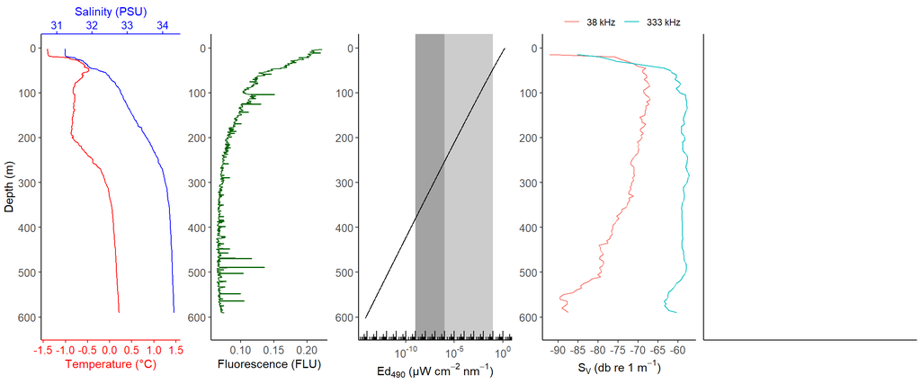

```r
# Coefficients for scaling salinity so that it can be plotted with temperature
b <- diff(c(-2, 2))/diff(c(30, 35))
a <- -2 - b * 30
# CTD plot
p_CTD <- CTD %>%
  filter(cast_number == 26) %>%
  ggplot() +
  # Temperature
  geom_path(aes(x = te90, y = depth, group = cast_number), col = "red", na.rm = T) +
  # Salinity
  geom_path(aes(x = a + psal * b, y = depth, group = cast_number), col = "blue", na.rm = T) +
  # Cast need to account for time of day
  # ggtitle("Salinity off scale") +
  # Scales
  scale_x_continuous("Temperature (°C)", breaks = seq(-2, 10, 0.5),
                     sec.axis = sec_axis(~ (. - a)/b, name = "Salinity (PSU)",
                                         breaks = seq(0, 40, 1))) +
  scale_y_reverse("Depth (m)", limits = c(620, 0), breaks = seq(0, 1500, 100)) +
  theme(axis.line.x.bottom = element_line(color = "red"),
        axis.ticks.x.bottom = element_line(color = "red"),
        axis.text.x.bottom = element_text(color = "red"),
        axis.title.x.bottom = element_text(color = "red"),
        axis.line.x.top = element_line(color = "blue"),
        axis.ticks.x.top = element_line(color = "blue"),
        axis.text.x.top = element_text(color = "blue"),
        axis.title.x.top = element_text(color = "blue"))

# Fluorescence
p_fluo <- CTD %>%
  filter(cast_number == 26) %>%
  ggplot() +
  # Fluorescence
  geom_path(aes(x = fluo, y = depth, group = cast_number), col = "darkgreen", na.rm = T) +
  # Scales
  scale_x_continuous("Fluorescence (FLU)") +
  scale_y_reverse(limits = c(620, 0), breaks = seq(0, 1500, 100)) +
  theme(axis.title.y = element_blank())

# COPS
p_COPS <- COPS_extra %>%
  filter(station == "DE420" & wavelength == 490) %>%
  # Calculate mean profile over several casts at 490 nm
  group_by(wavelength, depth) %>%
  summarize(edz_kz_mean = mean(edz_kz_mean),
            edz_kz_max = mean(edz_kz_max)) %>%
  ggplot() +
  # Edz profile
  geom_path(aes(x = edz_kz_mean, y = depth), col = "black") +
  # Mesopelagic zone defined by Kaartvedt et al. 2019
  annotate("rect", xmin = 10^-9, xmax = 10^-1, ymin = -Inf, ymax = Inf,
           fill = "black", alpha = 0.2) +
  # Results from Asknes et al. 2017
  annotate("rect", xmin = 10^-9, xmax = 10^-6, ymin = -Inf, ymax = Inf,
           fill = "black", alpha = 0.2) +
  # Cast need to account for time of day
  # ggtitle("Need to be corrected\nwith Trios") +
  # Scales
  scale_x_log10(expression("Ed"[490]*" (µW cm"^-2*" nm"^-1*")"),
                breaks = scales::trans_breaks("log10", function(x) 10 ^ x),
                labels = scales::trans_format("log10", scales::math_format(10 ^ .x))) +
  annotation_logticks(sides = "b") +
  scale_y_reverse(limits = c(620, 0), breaks = seq(0, 1500, 100)) +
  theme(axis.title.y = element_blank())

# WBAT
p_WBAT <- WBAT %>%
  # Correct labels
  mutate(frequency = factor(paste0(frequency, " kHz"),
                            levels = c("38 kHz", "333 kHz"))) %>%
  filter(cast_number == 26) %>%
  # Calculate median Sv over the whole range (10-95m @38 kHz and 10-60m @ 333 kHz)
  group_by(depth_round, frequency) %>%
  summarise(Sv_mean = 10 * log10(mean(10 ^ (Sv_cor_mean / 10)))) %>%
  ungroup() %>%
  ggplot() +
  # Sv at 38 and 333 kHz
  geom_path(aes(x = Sv_mean, y = depth_round, col = frequency)) +
  # Scales
  scale_x_continuous(expression("S"[V]*" (db re 1 m"^-1*")"), breaks = seq(-150, 0, 5)) +
  scale_y_reverse(limits = c(620, 0), breaks = seq(0, 1500, 100)) +
  theme(legend.position = "top",
        legend.title = element_blank(),
        axis.title.y = element_blank())

# UVP
p_UVP <- UVP %>%
  filter(cast_number == 26) %>%
  ggplot()# +
  # # Count per 5 m depth
  # geom_point(aes(x = taxa, y = depth_round, size = count, col = taxa), alpha = 0.5) +
  # # Scales
  # scale_x_discrete("Taxa") +
  # scale_y_reverse(limits = c(620, 0), breaks = seq(0, 1500, 100)) +
  # scale_size("Count", range = c(1.5, 10)) +
  # scale_color_viridis_d(option = "mako", begin = 0.1, end = 0.8) +
  # guides(color = "none",
  #        size = guide_legend(label.position = "top", label.vjust = -1)) +
  # theme(legend.position = "top",
  #       axis.title.y = element_blank(),
  #       axis.text.x = element_text(angle = -45, hjust = 0, vjust = 0.5))

# Combine plots
plot_grid(p_CTD, p_fluo, p_COPS, p_WBAT, p_UVP, nrow = 1, align = "h",
          axis = "tblr", rel_widths = c(1, 0.8, 1, 1, 1.2))
```

```r
# Remove unused data
rm(a, b, p_CTD, p_fluo, p_COPS, p_WBAT, p_UVP)
```

### Dusk - CTD28

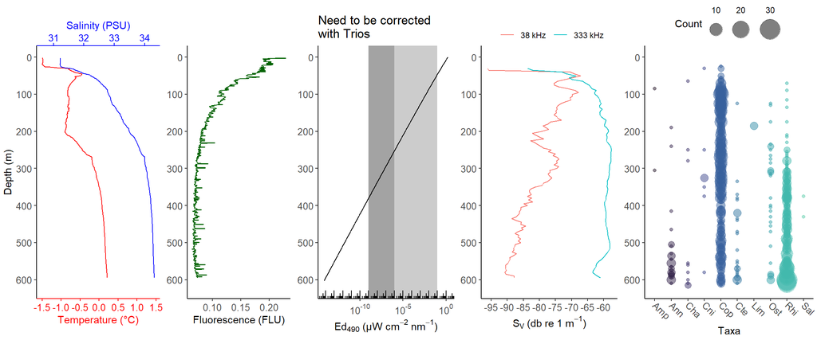

```r
# Coefficients for scaling salinity so that it can be plotted with temperature
b <- diff(c(-2, 2))/diff(c(30, 35))
a <- -2 - b * 30
# CTD plot
p_CTD <- CTD %>%
  filter(cast_number == 28) %>%
  ggplot() +
  # Temperature
  geom_path(aes(x = te90, y = depth, group = cast_number), col = "red", na.rm = T) +
  # Salinity
  geom_path(aes(x = a + psal * b, y = depth, group = cast_number), col = "blue", na.rm = T) +
  # Cast need to account for time of day
  # ggtitle("Salinity off scale") +
  # Scales
  scale_x_continuous("Temperature (°C)", breaks = seq(-2, 10, 0.5),
                     sec.axis = sec_axis(~ (. - a)/b, name = "Salinity (PSU)",
                                         breaks = seq(0, 40, 1))) +
  scale_y_reverse("Depth (m)", limits = c(620, 0), breaks = seq(0, 1500, 100)) +
  theme(axis.line.x.bottom = element_line(color = "red"),
        axis.ticks.x.bottom = element_line(color = "red"),
        axis.text.x.bottom = element_text(color = "red"),
        axis.title.x.bottom = element_text(color = "red"),
        axis.line.x.top = element_line(color = "blue"),
        axis.ticks.x.top = element_line(color = "blue"),
        axis.text.x.top = element_text(color = "blue"),
        axis.title.x.top = element_text(color = "blue"))

# Fluorescence
p_fluo <- CTD %>%
  filter(cast_number == 28) %>%
  ggplot() +
  # Fluorescence
  geom_path(aes(x = fluo, y = depth, group = cast_number), col = "darkgreen", na.rm = T) +
  # Scales
  scale_x_continuous("Fluorescence (FLU)") +
  scale_y_reverse(limits = c(620, 0), breaks = seq(0, 1500, 100)) +
  theme(axis.title.y = element_blank())

# COPS
p_COPS <- COPS_extra %>%
  filter(station == "DE420" & wavelength == 490) %>%
  # Calculate mean profile over several casts at 490 nm
  group_by(wavelength, depth) %>%
  summarize(edz_kz_mean = mean(edz_kz_mean),
            edz_kz_max = mean(edz_kz_max)) %>%
  ggplot() +
  # Edz profile
  geom_path(aes(x = edz_kz_mean, y = depth), col = "black") +
  # Mesopelagic zone defined by Kaartvedt et al. 2019
  annotate("rect", xmin = 10^-9, xmax = 10^-1, ymin = -Inf, ymax = Inf,
           fill = "black", alpha = 0.2) +
  # Results from Asknes et al. 2017
  annotate("rect", xmin = 10^-9, xmax = 10^-6, ymin = -Inf, ymax = Inf,
           fill = "black", alpha = 0.2) +
  # Cast need to account for time of day
  ggtitle("Need to be corrected\nwith Trios") +
  # Scales
  scale_x_log10(expression("Ed"[490]*" (µW cm"^-2*" nm"^-1*")"),
                breaks = scales::trans_breaks("log10", function(x) 10 ^ x),
                labels = scales::trans_format("log10", scales::math_format(10 ^ .x))) +
  annotation_logticks(sides = "b") +
  scale_y_reverse(limits = c(620, 0), breaks = seq(0, 1500, 100)) +
  theme(axis.title.y = element_blank())

# WBAT
p_WBAT <- WBAT %>%
  # Correct labels
  mutate(frequency = factor(paste0(frequency, " kHz"),
                            levels = c("38 kHz", "333 kHz"))) %>%
  filter(cast_number == 28) %>%
  # Calculate median Sv over the whole range (10-95m @38 kHz and 10-60m @ 333 kHz)
  group_by(depth_round, frequency) %>%
  summarise(Sv_mean = 10 * log10(mean(10 ^ (Sv_cor_mean / 10)))) %>%
  ungroup() %>%
  ggplot() +
  # Sv at 38 and 333 kHz
  geom_path(aes(x = Sv_mean, y = depth_round, col = frequency)) +
  # Scales
  scale_x_continuous(expression("S"[V]*" (db re 1 m"^-1*")"), breaks = seq(-150, 0, 5)) +
  scale_y_reverse(limits = c(620, 0), breaks = seq(0, 1500, 100)) +
  theme(legend.position = "top",
        legend.title = element_blank(),
        axis.title.y = element_blank())

# UVP
p_UVP <- UVP %>%
  filter(cast_number == 28) %>%
  ggplot() +
  # Count per 5 m depth
  geom_point(aes(x = taxa, y = depth_round, size = count, col = taxa), alpha = 0.5) +
  # Scales
  scale_x_discrete("Taxa") +
  scale_y_reverse(limits = c(620, 0), breaks = seq(0, 1500, 100)) +
  scale_size("Count", range = c(1.5, 10)) +
  scale_color_viridis_d(option = "mako", begin = 0.1, end = 0.8) +
  guides(color = "none",
         size = guide_legend(label.position = "top", label.vjust = -1)) +
  theme(legend.position = "top",
        axis.title.y = element_blank(),
        axis.text.x = element_text(angle = -45, hjust = 0, vjust = 0.5))

# Combine plots
plot_grid(p_CTD, p_fluo, p_COPS, p_WBAT, p_UVP, nrow = 1, align = "h",
          axis = "tblr", rel_widths = c(1, 0.8, 1, 1, 1.2))
```

```r
# Remove unused data
rm(a, b, p_CTD, p_fluo, p_COPS, p_WBAT, p_UVP)
```

### Night - CTD29

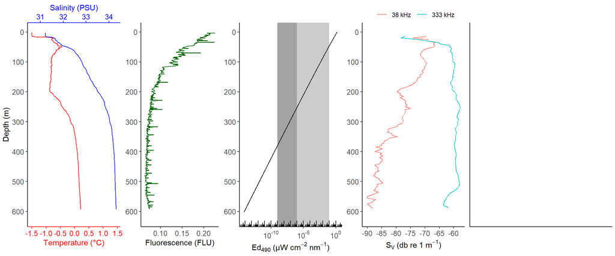

```r
# Coefficients for scaling salinity so that it can be plotted with temperature
b <- diff(c(-2, 2))/diff(c(30, 35))
a <- -2 - b * 30
# CTD plot
p_CTD <- CTD %>%
  filter(cast_number == 29) %>%
  ggplot() +
  # Temperature
  geom_path(aes(x = te90, y = depth, group = cast_number), col = "red", na.rm = T) +
  # Salinity
  geom_path(aes(x = a + psal * b, y = depth, group = cast_number), col = "blue", na.rm = T) +
  # Cast need to account for time of day
  # ggtitle("Salinity off scale") +
  # Scales
  scale_x_continuous("Temperature (°C)", breaks = seq(-2, 10, 0.5),
                     sec.axis = sec_axis(~ (. - a)/b, name = "Salinity (PSU)",
                                         breaks = seq(0, 40, 1))) +
  scale_y_reverse("Depth (m)", limits = c(620, 0), breaks = seq(0, 1500, 100)) +
  theme(axis.line.x.bottom = element_line(color = "red"),
        axis.ticks.x.bottom = element_line(color = "red"),
        axis.text.x.bottom = element_text(color = "red"),
        axis.title.x.bottom = element_text(color = "red"),
        axis.line.x.top = element_line(color = "blue"),
        axis.ticks.x.top = element_line(color = "blue"),
        axis.text.x.top = element_text(color = "blue"),
        axis.title.x.top = element_text(color = "blue"))

# Fluorescence
p_fluo <- CTD %>%
  filter(cast_number == 29) %>%
  ggplot() +
  # Fluorescence
  geom_path(aes(x = fluo, y = depth, group = cast_number), col = "darkgreen", na.rm = T) +
  # Scales
  scale_x_continuous("Fluorescence (FLU)") +
  scale_y_reverse(limits = c(620, 0), breaks = seq(0, 1500, 100)) +
  theme(axis.title.y = element_blank())

# COPS
p_COPS <- COPS_extra %>%
  filter(station == "DE420" & wavelength == 490) %>%
  # Calculate mean profile over several casts at 490 nm
  group_by(wavelength, depth) %>%
  summarize(edz_kz_mean = mean(edz_kz_mean),
            edz_kz_max = mean(edz_kz_max)) %>%
  ggplot() +
  # Edz profile
  geom_path(aes(x = edz_kz_mean, y = depth), col = "black") +
  # Mesopelagic zone defined by Kaartvedt et al. 2019
  annotate("rect", xmin = 10^-9, xmax = 10^-1, ymin = -Inf, ymax = Inf,
           fill = "black", alpha = 0.2) +
  # Results from Asknes et al. 2017
  annotate("rect", xmin = 10^-9, xmax = 10^-6, ymin = -Inf, ymax = Inf,
           fill = "black", alpha = 0.2) +
  # Cast need to account for time of day
  # ggtitle("Need to be corrected\nwith Trios") +
  # Scales
  scale_x_log10(expression("Ed"[490]*" (µW cm"^-2*" nm"^-1*")"),
                breaks = scales::trans_breaks("log10", function(x) 10 ^ x),
                labels = scales::trans_format("log10", scales::math_format(10 ^ .x))) +
  annotation_logticks(sides = "b") +
  scale_y_reverse(limits = c(620, 0), breaks = seq(0, 1500, 100)) +
  theme(axis.title.y = element_blank())

# WBAT
p_WBAT <- WBAT %>%
  # Correct labels
  mutate(frequency = factor(paste0(frequency, " kHz"),
                            levels = c("38 kHz", "333 kHz"))) %>%
  filter(cast_number == 29) %>%
  # Calculate median Sv over the whole range (10-95m @38 kHz and 10-60m @ 333 kHz)
  group_by(depth_round, frequency) %>%
  summarise(Sv_mean = 10 * log10(mean(10 ^ (Sv_cor_mean / 10)))) %>%
  ungroup() %>%
  ggplot() +
  # Sv at 38 and 333 kHz
  geom_path(aes(x = Sv_mean, y = depth_round, col = frequency)) +
  # Scales
  scale_x_continuous(expression("S"[V]*" (db re 1 m"^-1*")"), breaks = seq(-150, 0, 5)) +
  scale_y_reverse(limits = c(620, 0), breaks = seq(0, 1500, 100)) +
  theme(legend.position = "top",
        legend.title = element_blank(),
        axis.title.y = element_blank())

# UVP
p_UVP <- UVP %>%
  filter(cast_number == 29) %>%
  ggplot()# +
  # # Count per 5 m depth
  # geom_point(aes(x = taxa, y = depth_round, size = count, col = taxa), alpha = 0.5) +
  # # Scales
  # scale_x_discrete("Taxa") +
  # scale_y_reverse(limits = c(620, 0), breaks = seq(0, 1500, 100)) +
  # scale_size("Count", range = c(1.5, 10)) +
  # scale_color_viridis_d(option = "mako", begin = 0.1, end = 0.8) +
  # guides(color = "none",
  #        size = guide_legend(label.position = "top", label.vjust = -1)) +
  # theme(legend.position = "top",
  #       axis.title.y = element_blank(),
  #       axis.text.x = element_text(angle = -45, hjust = 0, vjust = 0.5))

# Combine plots
plot_grid(p_CTD, p_fluo, p_COPS, p_WBAT, p_UVP, nrow = 1, align = "h",
          axis = "tblr", rel_widths = c(1, 0.8, 1, 1, 1.2))
```

```r
# Remove unused data
rm(a, b, p_CTD, p_fluo, p_COPS, p_WBAT, p_UVP)
```

## BB2

There was no C-OPS data for BB2.

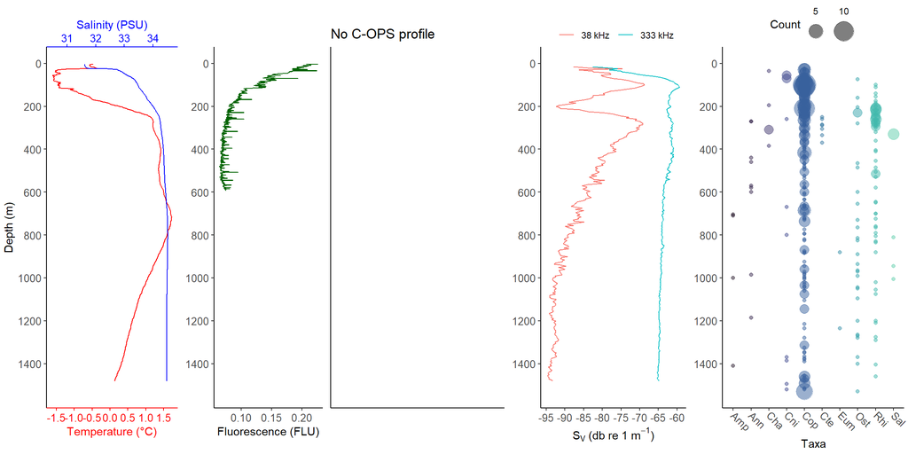

```r
# Coefficients for scaling salinity so that it can be plotted with temperature
b <- diff(c(-2, 2))/diff(c(30, 35))
a <- -2 - b * 30
# CTD plot
p_CTD <- CTD %>%
  filter(cast_number == 40) %>%
  ggplot() +
  # Temperature
  geom_path(aes(x = te90, y = depth, group = cast_number), col = "red", na.rm = T) +
  # Salinity
  geom_path(aes(x = a + psal * b, y = depth, group = cast_number), col = "blue", na.rm = T) +
  # Cast need to account for time of day
  # ggtitle("Salinity off scale") +
  # Scales
  scale_x_continuous("Temperature (°C)", breaks = seq(-2, 10, 0.5),
                     sec.axis = sec_axis(~ (. - a)/b, name = "Salinity (PSU)",
                                         breaks = seq(0, 40, 1))) +
  scale_y_reverse("Depth (m)", limits = c(1530, 0), breaks = seq(0, 1500, 200)) +
  theme(axis.line.x.bottom = element_line(color = "red"),
        axis.ticks.x.bottom = element_line(color = "red"),
        axis.text.x.bottom = element_text(color = "red"),
        axis.title.x.bottom = element_text(color = "red"),
        axis.line.x.top = element_line(color = "blue"),
        axis.ticks.x.top = element_line(color = "blue"),
        axis.text.x.top = element_text(color = "blue"),
        axis.title.x.top = element_text(color = "blue"))

# Fluorescence
p_fluo <- CTD %>%
  filter(cast_number == 29) %>%
  ggplot() +
  # Fluorescence
  geom_path(aes(x = fluo, y = depth, group = cast_number), col = "darkgreen", na.rm = T) +
  # Scales
  scale_x_continuous("Fluorescence (FLU)") +
  scale_y_reverse(limits = c(1530, 0), breaks = seq(0, 1500, 200)) +
  theme(axis.title.y = element_blank())

# COPS
p_COPS <- COPS_extra %>%
  filter(station == "BB2" & wavelength == 490) %>%
  # Calculate mean profile over several casts at 490 nm
  # group_by(wavelength, depth) %>%
  # summarize(edz_kz_mean = mean(edz_kz_mean),
  #           edz_kz_max = mean(edz_kz_max)) %>%
  ggplot() +
  # # Edz profile
  # geom_path(aes(x = edz_kz_mean, y = depth), col = "black") +
  # # Mesopelagic zone defined by Kaartvedt et al. 2019
  # annotate("rect", xmin = 10^-9, xmax = 10^-1, ymin = -Inf, ymax = Inf,
  #          fill = "black", alpha = 0.2) +
  # # Results from Asknes et al. 2017
  # annotate("rect", xmin = 10^-9, xmax = 10^-6, ymin = -Inf, ymax = Inf,
  #          fill = "black", alpha = 0.2) +
  # Cast need to account for time of day
  ggtitle("No C-OPS profile") #+
  # # Scales
  # scale_x_log10(expression("Ed"[490]*" (µW cm"^-2*" nm"^-1*")"),
  #               breaks = scales::trans_breaks("log10", function(x) 10 ^ x),
  #               labels = scales::trans_format("log10", scales::math_format(10 ^ .x))) +
  # annotation_logticks(sides = "b") +
  # scale_y_reverse(limits = c(620, 0), breaks = seq(0, 1500, 100)) +
  # theme(axis.title.y = element_blank())

# WBAT
p_WBAT <- WBAT %>%
  # Correct labels
  mutate(frequency = factor(paste0(frequency, " kHz"),
                            levels = c("38 kHz", "333 kHz"))) %>%
  filter(cast_number == 40) %>%
  # Calculate median Sv over the whole range (10-95m @38 kHz and 10-60m @ 333 kHz)
  group_by(depth_round, frequency) %>%
  summarise(Sv_mean = 10 * log10(mean(10 ^ (Sv_cor_mean / 10)))) %>%
  ungroup() %>%
  ggplot() +
  # Sv at 38 and 333 kHz
  geom_path(aes(x = Sv_mean, y = depth_round, col = frequency)) +
  # Scales
  scale_x_continuous(expression("S"[V]*" (db re 1 m"^-1*")"), breaks = seq(-150, 0, 5)) +
  scale_y_reverse(limits = c(1530, 0), breaks = seq(0, 1500, 200)) +
  theme(legend.position = "top",
        legend.title = element_blank(),
        axis.title.y = element_blank())

# UVP
p_UVP <- UVP %>%
  filter(cast_number == 40) %>%
  ggplot() +
  # Count per 5 m depth
  geom_point(aes(x = taxa, y = depth_round, size = count, col = taxa), alpha = 0.5) +
  # Scales
  scale_x_discrete("Taxa") +
  scale_y_reverse(limits = c(1530, 0), breaks = seq(0, 1500, 200)) +
  scale_size("Count", range = c(1.5, 10)) +
  scale_color_viridis_d(option = "mako", begin = 0.1, end = 0.8) +
  guides(color = "none",
         size = guide_legend(label.position = "top", label.vjust = -1)) +
  theme(legend.position = "top",
        axis.title.y = element_blank(),
        axis.text.x = element_text(angle = -45, hjust = 0, vjust = 0.5))

# Combine plots
plot_grid(p_CTD, p_fluo, p_COPS, p_WBAT, p_UVP, nrow = 1, align = "h",
          axis = "tblr", rel_widths = c(1, 0.8, 1, 1, 1.2))
```

```r
# Remove unused data
rm(a, b, p_CTD, p_fluo, p_COPS, p_WBAT, p_UVP)
```